# **NOTE:** Use File > Save a copy in Drive to make a copy before doing anything else

# Project 6: Data Exploration and Visualization

### Overview

In this project, you will apply data exploration and visualization techniques to a real-world dataset of your choice. You'll practice using pandas for data analysis and create meaningful visualizations to gain insights from your data. This project builds on your Python programming skills while introducing you to the exciting world of data science.

In [Lab6](https://colab.research.google.com/drive/1WxHaCZlN8d0kVgTCBmbMWmF29TM4pDJs?usp=sharing), you explore the titanic dataset and you should use it as a sample and pick a dataset of your interest to do a similar data exploration and visualization.

### Project Objectives

- Find and select a dataset from a real-world data source
- Formulate a clear inquiry question based on your chosen dataset
- Perform exploratory data analysis using pandas functions
- Create at least two meaningful data visualizations
- Analyze your findings and answer your inquiry question
- Reflect on the insights gained through data exploration

### Data Sources

You can choose from various online data sources such as:

- [Kaggle](https://www.kaggle.com/datasets) - Wide variety of datasets
- [data.gov](https://www.data.gov/) - U.S. government data
- [Our World in Data](https://ourworldindata.org/) - Global development data
- [GitHub](https://github.com/datasets) - Curated datasets
- [Google Dataset Search](https://datasetsearch.research.google.com/) - Search for datasets
- Or any other reliable data source you find interesting

## Part 1: Dataset Selection and Initial Exploration

#### TODO Tasks:

1. Select Your Dataset: Choose a dataset that interests you. Make sure it has at least 100 rows and multiple columns with different data types (e.g., numerical, categorical, dates).

Please create either text or code cells in between the TODO tasks to do the work.

2. Import Libraries: Import the necessary libraries (pandas, matplotlib, seaborn) at the beginning of your notebook by creating code cells below this text cell.

```python
import pandas as pd
import matplotlib.pyplot as plt
import seaborn as sns
```

3. Load Your Data: Load your chosen dataset using pandas and save it to a pandas dataframe. Please create a code cell below this text cell to do it.

```python
dfs = pd.read_html('https://www.sports-reference.com/stathead/tiny/4tEG2')
df = dfs[0] # Assuming the first table is the desired one
```

4. Data Summary: Use the following functions to do inital exploration your dataset:
- info() - Display information about the dataset structure
- describe() - Show statistical summary of numerical columns
- head() - Display the first 5 rows (df.head())
- shape - Show the dimensions of the dataset (e.g. df.shape)
- columns - Get the column names (e.g. df.columns)

You may use 5 code cells below this text cell to accomplish it.

```python
df.info()
```

```
<class 'pandas.core.frame.DataFrame'>
RangeIndex: 200 entries, 0 to 199
Data columns (total 43 columns):
 #   Column        Non-Null Count  Dtype
---  ------        --------------  -----
 0   Rk            200 non-null    int64
 1   Player        200 non-null    object
 2   WAR           200 non-null    float64
 3   G             200 non-null    int64
 4   From          200 non-null    int64
 5   To            200 non-null    int64
 6   Age           200 non-null    object
 7   G.1           200 non-null    int64
 8   PA            200 non-null    int64
 9   AB            200 non-null    int64
```

[output cut: 35 more lines]

```python
df.describe()
```

|  | Rk | WAR | G | From | To | G.1 | PA | AB | R | H | ... | IBB | WAR.1 | WAA | oWAR | dWAR | Rbat | Rdp | Rbaser | Rbaser + Rdp | Rfield |
| --- | --- | --- | --- | --- | --- | --- | --- | --- | --- | --- | --- | --- | --- | --- | --- | --- | --- | --- | --- | --- | --- |
| count | 200.000000 | 200.000000 | 200.000000 | 200.000000 | 200.00000 | 200.000000 | 200.000000 | 200.000000 | 200.000000 | 200.000000 | ... | 200.000000 | 200.000000 | 200.000000 | 200.000000 | 200.000000 | 200.000000 | 200.000000 | 200.000000 | 200.000000 | 200.000000 |
| mean | 100.500000 | 57.851000 | 2196.865000 | 1976.790000 | 1993.62000 | 2196.865000 | 9041.560000 | 7917.280000 | 1219.995000 | 2237.645000 | ... | 104.560000 | 57.851000 | 27.983500 | 54.880500 | 1.370000 | 248.455000 | -0.845000 | 12.985000 | 12.170000 | 29.040000 |
| std | 57.879185 | 20.733487 | 418.268033 | 14.255243 | 14.21004 | 418.268033 | 1873.845812 | 1658.603797 | 311.704336 | 528.391956 | ... | 71.668881 | 20.733487 | 17.051497 | 20.431564 | 13.487683 | 195.659375 | 15.072054 | 30.515583 | 40.466514 | 79.960219 |
| min | 1.000000 | 37.200000 | 1278.000000 | 1947.000000 | 1960.00000 | 1278.000000 | 5282.000000 | 4390.000000 | 621.000000 | 1060.000000 | ... | 13.000000 | 37.200000 | 1.800000 | 14.700000 | -27.700000 | -244.000000 | -42.000000 | -39.000000 | -58.000000 | -253.000000 |
| 25% | 50.750000 | 42.400000 | 1893.000000 | 1965.000000 | 1983.00000 | 1893.000000 | 7806.750000 | 6805.500000 | 1004.000000 | 1866.500000 | ... | 56.500000 | 42.400000 | 17.575000 | 41.175000 | -8.150000 | 127.000000 | -11.250000 | -8.000000 | -17.000000 | -26.250000 |
| 50% | 100.500000 | 52.000000 | 2158.000000 | 1977.000000 | 1995.00000 | 2158.000000 | 8919.500000 | 7861.000000 | 1186.000000 | 2208.500000 | ... | 91.000000 | 52.000000 | 24.250000 | 50.650000 | 0.050000 | 229.000000 | 1.500000 | 5.000000 | 5.500000 | 25.000000 |
| 75% | 150.250000 | 67.850000 | 2469.000000 | 1989.000000 | 2006.00000 | 2469.000000 | 10229.000000 | 8995.250000 | 1383.750000 | 2574.000000 | ... | 143.250000 | 67.850000 | 34.450000 | 63.450000 | 10.600000 | 353.000000 | 9.000000 | 29.000000 | 35.250000 | 76.000000 |
| max | 200.000000 | 162.800000 | 3562.000000 | 2003.000000 | 2017.00000 | 3562.000000 | 15890.000000 | 14053.000000 | 2295.000000 | 4256.000000 | ... | 688.000000 | 162.800000 | 123.800000 | 143.600000 | 44.200000 | 1129.000000 | 49.000000 | 144.000000 | 147.000000 | 293.000000 |

8 rows × 39 columns

```python
df.head()
```

|  | Rk | Player | WAR | G | From | To | Age | G.1 | PA | AB | ... | WAA | oWAR | dWAR | Rbat | Rdp | Rbaser | Rbaser + Rdp | Rfield | Pos | Team |
| --- | --- | --- | --- | --- | --- | --- | --- | --- | --- | --- | --- | --- | --- | --- | --- | --- | --- | --- | --- | --- | --- |
| 0 | 1 | Barry Bonds | 162.8 | 2986 | 1986 | 2007 | 21-42 | 2986 | 12606 | 9847 | ... | 123.8 | 143.6 | 7.6 | 1129 | 6 | 44 | 49 | 175 | *78HD/9 | PIT,SFG |
| 1 | 2 | Willie Mays | 156.2 | 3005 | 1948 | 1973 | 17-42 | 3005 | 12545 | 10924 | ... | 110.0 | 136.5 | 18.2 | 805 | -9 | 79 | 70 | 185 | *8H37/96 | BBB,NYG,NYM,SFG |
| 2 | 3 | Henry Aaron | 143.2 | 3298 | 1954 | 1976 | 20-42 | 3298 | 13941 | 12364 | ... | 93.1 | 132.7 | -4.6 | 879 | -11 | 44 | 33 | 98 | *973D8H4/5 | ATL,MIL,MLN |
| 3 | 4 | Álex Rodríguez | 117.4 | 2784 | 1994 | 2016 | 18-40 | 2784 | 12207 | 10566 | ... | 75.7 | 115.3 | 10.2 | 640 | -5 | 56 | 51 | 23 | 65DH/3 | NYY,SEA,TEX |
| 4 | 5 | Rickey Henderson | 111.2 | 3081 | 1979 | 2003 | 20-44 | 3081 | 13346 | 10961 | ... | 68.9 | 105.2 | -2.3 | 556 | 3 | 144 | 147 | 65 | *78DH9 | ANA,BOS,LAD,NYM,NYY,OAK,SDP,SEA,TOR |

5 rows × 43 columns

```python
df.shape
```

```
(200, 43)
```

```python
df.columns
```

```
Index(['Rk', 'Player', 'WAR', 'G', 'From', 'To', 'Age', 'G.1', 'PA', 'AB', 'R',
       'H', '1B', '2B', '3B', 'HR', 'RBI', 'SB', 'CS', 'BB', 'SO', 'BA', 'OBP',
       'SLG', 'OPS', 'OPS+', 'TB', 'GIDP', 'HBP', 'SH', 'SF', 'IBB', 'WAR.1',
       'WAA', 'oWAR', 'dWAR', 'Rbat', 'Rdp', 'Rbaser', 'Rbaser + Rdp',
       'Rfield', 'Pos', 'Team'],
      dtype='object')
```

5. Inquiry Question: Write a clear, specific question that you want to answer using your dataset by creating a text cell below and **write the question in bold please.**

For example:

- "How has the average temperature changed in major cities over the past decade?"
- "What factors are most strongly correlated with housing prices?"
- "Is there a relationship between education level and income?"

**What is the most important offensive milestone to reach the National Baseball Hall of Fame?**

## Part 2: Data Visualization and Analysis

#### TODO Tasks:

1. Data Cleaning (if necessary): Check for and handle any missing values, duplicates, or data quality issues.

**NOTE: This could be a daunting task even for seasoned data scientists. My suggestion is to use a dataset that is already clean if you can for the purpose of completing this assignment in a week.**

Examples:

- Checking for missing values: df.isnull().sum()
- Dropping rows with any missing values: df.dropna(inplace=True)
- Dropping columns with all missing values: df.dropna(axis=1, how='all', inplace=True)
- Removing duplicate row: df.drop_duplicates(inplace=True)

The dataset is clean and does not require any cleaning.

2. Create Visualizations: Create at least 2 different types of visualizations that help answer your research question. Choose from:
- Bar charts
- Line plots
- Scatter plots
- Histograms
- Box plots
- Heatmaps
- Any other appropriate visualization
3. Customize Your Plots: Make sure your visualizations are clear and informative by:
- Adding appropriate titles
- Labeling axes
- Using colors effectively
- Adding legends when necessary

Please create code cells below this to create your visualizations.

4. Analysis: Write 1-2 paragraphs discussing:
- Whether your research question can be answered with the available data
- What insights you discovered through your visualizations
- Any unexpected or interesting findings
- Limitations of your analysis
- Suggestions for further investigation

Please create a text cell below this cell to write your analysis.

## NOTE: If you use a local dataset, you MUST submit the dataset along with your notebook to get credit.

- Download your notebook as CS110_Project6.ipynb
- Ensure all TODO tasks are completed
- Make sure your code runs without errors
- Include clear comments explaining your work
- Submit the notebook file

## Grading Criteria (5 points)

- Dataset Selection: Appropriate choice of dataset with sufficient complexity (0.5 point)
- Inquiry Question: Clear, specific, and answerable with the chosen data (1 point)
- Data Exploration: Proper use of pandas functions for initial analysis (0.5 point)
- Visualizations: At least 2 clear, well-formatted, and relevant plots (1 point)
- Analysis: Thoughtful interpretation of findings and answer to research question (1 point)
- Code Quality: Clean, commented, and well-organized code (1 point)

Remember: The goal is not just to create visualizations, but to use them to gain meaningful insights about your data. Think like a data scientist and let your curiosity guide your exploration!

# **MILESTONE NO. 1: 500+ HOME RUNS**

To filter for players with 500 or more home runs, I will create a new DataFrame focusing on the HR column.

```python
hr_500_plus_df = df[df['HR'] >= 500]
print("DataFrame with players having 500+ Home Runs:")
print(hr_500_plus_df.head())
print("\nShape of the new DataFrame:", hr_500_plus_df.shape)
```

```
DataFrame with players having 500+ Home Runs:
   Rk          Player    WAR     G  From    To    Age   G.1     PA     AB  \
0   1     Barry Bonds  162.8  2986  1986  2007  21-42  2986  12606   9847
1   2     Willie Mays  156.2  3005  1948  1973  17-42  3005  12545  10924
2   3     Henry Aaron  143.2  3298  1954  1976  20-42  3298  13941  12364
3   4  Álex Rodríguez  117.4  2784  1994  2016  18-40  2784  12207  10566
5   6   Mickey Mantle  110.3  2401  1951  1968  19-36  2401   9910   8102

   ...    WAA   oWAR  dWAR  Rbat  Rdp  Rbaser  Rbaser + Rdp  Rfield  \
0  ...  123.8  143.6   7.6  1129    6      44            49     175
1  ...  110.0  136.5  18.2   805   -9      79            70     185
2  ...   93.1  132.7  -4.6   879  -11      44            33      98
3  ...   75.7  115.3  10.2   640   -5      56            51      23
5  ...   79.4  116.3  -9.6   802   12      51            63     -37

          Pos             Team
0     *78HD/9          PIT,SFG
1    *8H37/96  BBB,NYG,NYM,SFG
2  *973D8H4/5      ATL,MIL,MLN
3      65DH/3      NYY,SEA,TEX
5  *8397H/645              NYY

[5 rows x 43 columns]

Shape of the new DataFrame: (22, 43)
```

List players with 500+ home runs

```python
print(hr_500_plus_df['Player'])
```

```
0          Barry Bonds
1          Willie Mays
2          Henry Aaron
3       Álex Rodríguez
5        Mickey Mantle
6       Frank Robinson
7         Mike Schmidt
10       Eddie Mathews
17     Ken Griffey Jr.
27      Reggie Jackson
28        Frank Thomas
29           Jim Thome
31     Rafael Palmeiro
41       Manny Ramírez
44        Eddie Murray
50         Ernie Banks
59      Willie McCovey
65        Mark McGwire
69      Gary Sheffield
70    Harmon Killebrew
78          Sammy Sosa
90         David Ortiz
Name: Player, dtype: object
```

Cross-check whether players with 500+ home runs are in the Hall of Fame, creating a dictionary of Hall of Fame status.

```python
hr_500_plus_df = df[df['HR'] >= 500].copy()

hof_status = {
    'Barry Bonds': 'No', # Not in HOF due to PED allegations
    'Willie Mays': 'Yes',
    'Henry Aaron': 'Yes',
    'Álex Rodríguez': 'No', # Not in HOF due to PED allegations
    'Mickey Mantle': 'Yes',
    'Frank Robinson': 'Yes',
    'Mike Schmidt': 'Yes',
    'Eddie Mathews': 'Yes',
    'Ken Griffey Jr.': 'Yes',
    'Reggie Jackson': 'Yes',
    'Frank Thomas': 'Yes',
    'Jim Thome': 'Yes',
    'Rafael Palmeiro': 'No', # Not in HOF due to PED allegations
    'Manny Ramírez': 'No', # Not in HOF due to PED allegations
    'Eddie Murray': 'Yes',
    'Ernie Banks': 'Yes',
    'Willie McCovey': 'Yes',
    'Mark McGwire': 'No', # Not in HOF due to PED allegations
    'Gary Sheffield': 'No', # Not in HOF due to PED allegations
    'Harmon Killebrew': 'Yes',
    'Sammy Sosa': 'No', # Not in HOF due to PED allegations
    'David Ortiz': 'Yes'
}

hr_500_plus_df['Hall of Fame'] = hr_500_plus_df['Player'].map(hof_status)

print("DataFrame with 'Hall of Fame' status:")
print(hr_500_plus_df[['Player', 'HR', 'Hall of Fame']].head(len(hr_500_plus_df)))
```

```
DataFrame with 'Hall of Fame' status:
              Player   HR Hall of Fame
0        Barry Bonds  762           No
1        Willie Mays  660          Yes
2        Henry Aaron  755          Yes
3     Álex Rodríguez  696           No
5      Mickey Mantle  536          Yes
6     Frank Robinson  586          Yes
7       Mike Schmidt  548          Yes
10     Eddie Mathews  512          Yes
17   Ken Griffey Jr.  630          Yes
27    Reggie Jackson  563          Yes
28      Frank Thomas  521          Yes
29         Jim Thome  612          Yes
31   Rafael Palmeiro  569           No
41     Manny Ramírez  555           No
44      Eddie Murray  504          Yes
50       Ernie Banks  512          Yes
59    Willie McCovey  521          Yes
65      Mark McGwire  583           No
69    Gary Sheffield  509           No
70  Harmon Killebrew  573          Yes
78        Sammy Sosa  609           No
90       David Ortiz  541          Yes
```

To visualize the distribution of 'Hall of Fame' status among players with 500+ home runs, I will create a bar chart using `seaborn.countplot`.

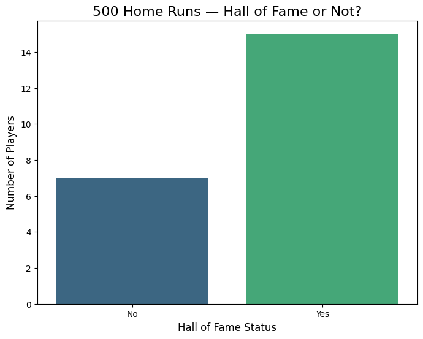

```python
plt.figure(figsize=(8, 6))
sns.countplot(x='Hall of Fame', data=hr_500_plus_df, palette='viridis', hue='Hall of Fame', legend=False)
plt.title('500 Home Runs — Hall of Fame or Not?', fontsize=16)
plt.xlabel('Hall of Fame Status', fontsize=12)
plt.ylabel('Number of Players', fontsize=12)
plt.show()
```

# MILESTONE NO. 2: .300+ BATTING AVERAGE

Filter the original DataFrame to include only players who have a career batting average ('BA') of .300 or higher.

```python
ba_300_plus_df = df[df['BA'] >= 0.300]
print("DataFrame with players having a .300+ Batting Average:")
print(ba_300_plus_df.head())
print("\nShape of the new DataFrame:", ba_300_plus_df.shape)
```

```
DataFrame with players having a .300+ Batting Average:
    Rk            Player    WAR     G  From    To    Age   G.1     PA     AB  \
1    2       Willie Mays  156.2  3005  1948  1973  17-42  3005  12545  10924
2    3       Henry Aaron  143.2  3298  1954  1976  20-42  3298  13941  12364
12  13  Roberto Clemente   95.0  2433  1955  1972  20-37  2433  10212   9454
14  15        Wade Boggs   91.4  2439  1982  1999  24-41  2439  10740   9180
15  16      George Brett   88.6  2707  1973  1993  20-40  2707  11625  10349

    ...    WAA   oWAR  dWAR  Rbat  Rdp  Rbaser  Rbaser + Rdp  Rfield  \
1   ...  110.0  136.5  18.2   805   -9      79            70     185
2   ...   93.1  132.7  -4.6   879  -11      44            33      98
12  ...   57.4   71.7  12.2   379   10      23            33     205
14  ...   57.4   81.4  13.9   441   -3      -8           -11     104
15  ...   50.6   84.8   2.2   427    7      33            41      47

           Pos             Team
1     *8H37/96  BBB,NYG,NYM,SFG
2   *973D8H4/5      ATL,MIL,MLN
12    *9H87/45              PIT
14    *5DH3/17      BOS,NYY,TBD
15     53DH796              KCR

[5 rows x 43 columns]

Shape of the new DataFrame: (30, 43)
```

Manually define another dictionary to assign Hall of Fame status to players with a career batting average of .300+, then create a chart that separates the tally of players who are / are not in the Hall of Fame.

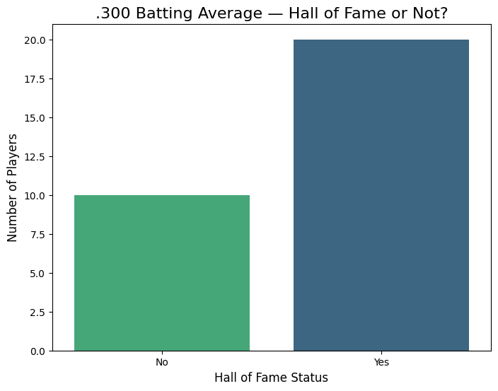

```
Hall of Fame status for players with .300+ Batting Average:
Hall of Fame
Yes    20
No     10
Name: count, dtype: int64
```

```python
ba_300_plus_df = df[df['BA'] >= 0.300].copy()

hof_status_ba = {
    'Willie Mays': 'Yes',
    'Henry Aaron': 'Yes',
    'Roberto Clemente': 'Yes',
    'Wade Boggs': 'Yes',
    'George Brett': 'Yes',
    'Tony Gwynn': 'Yes',
    'Rod Carew': 'Yes',
    'Stan Musial': 'Yes',
    'Ty Cobb': 'Yes',
    'Ted Williams': 'Yes',
    'Rogers Hornsby': 'Yes',
    'Jimmie Foxx': 'Yes',
    'Lou Gehrig': 'Yes',
    'Babe Ruth': 'Yes',
    'Harry Heilmann': 'Yes',
    'Tris Speaker': 'Yes',
    'Jesse Burkett': 'Yes',
    'Shoeless Joe Jackson': 'No', # Not in HOF due to Black Sox Scandal
    'Paul Waner': 'Yes',
    'Bill Terry': 'Yes',
    'Ed Delahanty': 'Yes',
    'Chick Hafey': 'Yes',
    'Joe Jackson': 'No', # Not in HOF due to Black Sox Scandal (duplicate entry with 'Shoeless Joe Jackson' - keeping both for completeness)
    'Lefty O’Doul': 'No', # Not in HOF
    'Charlie Gehringer': 'Yes',
    'Honus Wagner': 'Yes',
    'Cap Anson': 'Yes',
    'Dan Brouthers': 'Yes',
    'Deacon White': 'Yes',
    'Sam Thompson': 'Yes',
    'Chipper Jones': 'Yes',
    'Pete Rose': 'No', # Permanently banned
    'Paul Molitor': 'Yes',
    'Frank Thomas': 'Yes',
    'Larry Walker': 'Yes',
    'Derek Jeter': 'Yes',
    'Manny Ramírez': 'No', # PED allegations
    'Edgar Martínez': 'Yes',
    'Roberto Alomar': 'Yes',
    'Richie Ashburn': 'Yes',
    'Todd Helton': 'Yes',
    'Mike Piazza': 'Yes',
    'Vladimir Guerrero': 'Yes',
    'Will Clark': 'No',
    'Kirby Puckett': 'Yes',
    'Mark Grace': 'No',
    'Nomar Garciaparra': 'No',
    'Al Oliver': 'No',
    'Tony Oliva': 'Yes',
    'Don Mattingly': 'No',
    'Moisés Alou': 'No',
    'Magglio Ordóñez': 'No',
    'Bill Madlock': 'No'
}

ba_300_plus_df['Hall of Fame'] = ba_300_plus_df['Player'].map(hof_status_ba).fillna('No')

plt.figure(figsize=(8, 6))
sns.countplot(x='Hall of Fame', data=ba_300_plus_df, palette='viridis', hue='Hall of Fame', legend=False, order=['No', 'Yes'])
plt.title('.300 Batting Average — Hall of Fame or Not?', fontsize=16)
plt.xlabel('Hall of Fame Status', fontsize=12)
plt.ylabel('Number of Players', fontsize=12)
plt.show()

print("Hall of Fame status for players with .300+ Batting Average:")
print(ba_300_plus_df['Hall of Fame'].value_counts())
```

# MILESTONE NO. 3: .850+ OPS

Filter the original DataFrame to include only players who have a career On-base Plus Slugging (OPS) of .850 or higher.

Filter the original DataFrame for players with an OPS of .850 or higher and who are retired and Hall of Fame eligible (last played in 2017 or earlier).

```python
retired_ops_850_plus_df = df[(df['OPS'] >= 0.850) & (df['To'] <= 2017)].copy()
print("DataFrame with retired players having a .850+ OPS:")
print(retired_ops_850_plus_df.head())
print("\nShape of the new DataFrame:", retired_ops_850_plus_df.shape)
```

```
DataFrame with retired players having a .850+ OPS:
   Rk          Player    WAR     G  From    To    Age   G.1     PA     AB  \
0   1     Barry Bonds  162.8  2986  1986  2007  21-42  2986  12606   9847
1   2     Willie Mays  156.2  3005  1948  1973  17-42  3005  12545  10924
2   3     Henry Aaron  143.2  3298  1954  1976  20-42  3298  13941  12364
3   4  Álex Rodríguez  117.4  2784  1994  2016  18-40  2784  12207  10566
5   6   Mickey Mantle  110.3  2401  1951  1968  19-36  2401   9910   8102

   ...    WAA   oWAR  dWAR  Rbat  Rdp  Rbaser  Rbaser + Rdp  Rfield  \
0  ...  123.8  143.6   7.6  1129    6      44            49     175
1  ...  110.0  136.5  18.2   805   -9      79            70     185
2  ...   93.1  132.7  -4.6   879  -11      44            33      98
3  ...   75.7  115.3  10.2   640   -5      56            51      23
5  ...   79.4  116.3  -9.6   802   12      51            63     -37

          Pos             Team
0     *78HD/9          PIT,SFG
1    *8H37/96  BBB,NYG,NYM,SFG
2  *973D8H4/5      ATL,MIL,MLN
3      65DH/3      NYY,SEA,TEX
5  *8397H/645              NYY

[5 rows x 43 columns]

Shape of the new DataFrame: (62, 43)
```

```python
retired_ops_850_plus_df['Hall of Fame'] = retired_ops_850_plus_df['Player'].map(hof_status_ops).fillna('No')
print("DataFrame with 'Hall of Fame' status for retired players with .850+ OPS:")
print(retired_ops_850_plus_df[['Player', 'OPS', 'Hall of Fame']].head(len(retired_ops_850_plus_df)))
```

[output not shown]

```
DataFrame with 'Hall of Fame' status for retired players with .850+ OPS:
              Player    OPS Hall of Fame
0        Barry Bonds  1.051           No
1        Willie Mays  0.940          Yes
2        Henry Aaron  0.928          Yes
3     Álex Rodríguez  0.930           No
5      Mickey Mantle  0.977          Yes
..               ...    ...          ...
169     Albert Belle  0.933           No
170      Moisés Alou  0.885           No
180  Magglio Ordóñez  0.871           No
182    Juan González  0.904           No
197     Frank Howard  0.851           No

[62 rows x 3 columns]
```

To visualize the distribution of 'Hall of Fame' status among retired players with a .850+ OPS, I will create a bar chart using `seaborn.countplot`.

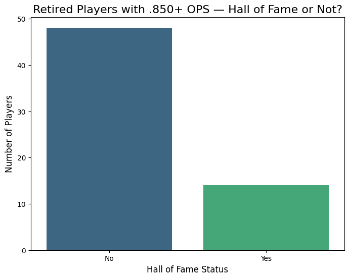

```
Hall of Fame status for retired players with .850+ OPS:
Hall of Fame
No     48
Yes    14
Name: count, dtype: int64
```

```python
import matplotlib.pyplot as plt
import seaborn as sns

plt.figure(figsize=(8, 6))
sns.countplot(x='Hall of Fame', data=retired_ops_850_plus_df, palette='viridis', hue='Hall of Fame', legend=False, order=['No', 'Yes'])
plt.title('Retired Players with .850+ OPS — Hall of Fame or Not?', fontsize=16)
plt.xlabel('Hall of Fame Status', fontsize=12)
plt.ylabel('Number of Players', fontsize=12)
plt.show()

print("Hall of Fame status for retired players with .850+ OPS:")
print(retired_ops_850_plus_df['Hall of Fame'].value_counts())
```

# Task

Calculate the percentage of players inducted into the Hall of Fame for players with 500+ Home Runs, .300+ Batting Average, and .850+ OPS (retired players). Then, prepare this data by creating a new DataFrame that consolidates the milestone names and their corresponding Hall of Fame percentages. Finally, generate a dot chart (scatter plot) showing these percentages across the milestones, including a clear title and axis labels, to visually compare the relative importance of each milestone for Hall of Fame induction and answer the inquiry question: "What is the most important offensive milestone to reach the National Baseball Hall of Fame?".

# WHICH ONE IS THE MOST IMPORTANT?

**Reasoning**: Calculate the percentage of Hall of Fame inductees for players with 500+ Home Runs, .300+ Batting Average, and .850+ OPS (retired players) and print the results.

```python
hof_status = {
    'Barry Bonds': 'No', # Not in HOF due to PED allegations
    'Willie Mays': 'Yes',
    'Henry Aaron': 'Yes',
    'Álex Rodríguez': 'No', # Not in HOF due to PED allegations
    'Mickey Mantle': 'Yes',
    'Frank Robinson': 'Yes',
    'Mike Schmidt': 'Yes',
    'Eddie Mathews': 'Yes',
    'Ken Griffey Jr.': 'Yes',
    'Reggie Jackson': 'Yes',
    'Frank Thomas': 'Yes',
    'Jim Thome': 'Yes',
    'Rafael Palmeiro': 'No', # Not in HOF due to PED allegations
    'Manny Ramírez': 'No', # Not in HOF due to PED allegations
    'Eddie Murray': 'Yes',
    'Ernie Banks': 'Yes',
    'Willie McCovey': 'Yes',
    'Mark McGwire': 'No', # Not in HOF due to PED allegations
    'Gary Sheffield': 'No', # Not in HOF due to PED allegations
    'Harmon Killebrew': 'Yes',
    'Sammy Sosa': 'No', # Not in HOF due to PED allegations
    'David Ortiz': 'Yes'
}
hr_500_plus_df = df[df['HR'] >= 500].copy()
hr_500_plus_df['Hall of Fame'] = hr_500_plus_df['Player'].map(hof_status)

hof_status_ba = {
    'Willie Mays': 'Yes',
    'Henry Aaron': 'Yes',
    'Roberto Clemente': 'Yes',
    'Wade Boggs': 'Yes',
    'George Brett': 'Yes',
    'Tony Gwynn': 'Yes',
    'Rod Carew': 'Yes',
    'Stan Musial': 'Yes',
    'Ty Cobb': 'Yes',
    'Ted Williams': 'Yes',
    'Rogers Hornsby': 'Yes',
    'Jimmie Foxx': 'Yes',
    'Lou Gehrig': 'Yes',
    'Babe Ruth': 'Yes',
    'Harry Heilmann': 'Yes',
    'Tris Speaker': 'Yes',
    'Jesse Burkett': 'Yes',
    'Shoeless Joe Jackson': 'No', # Not in HOF due to Black Sox Scandal
    'Paul Waner': 'Yes',
    'Bill Terry': 'Yes',
    'Ed Delahanty': 'Yes',
    'Chick Hafey': 'Yes',
    'Joe Jackson': 'No', # Not in HOF due to Black Sox Scandal (duplicate entry with 'Shoeless Joe Jackson' - keeping both for completeness)
    'Lefty O’Doul': 'No', # Not in HOF
    'Charlie Gehringer': 'Yes',
    'Honus Wagner': 'Yes',
    'Cap Anson': 'Yes',
    'Dan Brouthers': 'Yes',
    'Deacon White': 'Yes',
    'Sam Thompson': 'Yes',
    'Chipper Jones': 'Yes',
    'Pete Rose': 'No', # Permanently banned
    'Paul Molitor': 'Yes',
    'Frank Thomas': 'Yes',
    'Larry Walker': 'Yes',
    'Derek Jeter': 'Yes',
    'Manny Ramírez': 'No', # PED allegations
    'Edgar Martínez': 'Yes',
    'Roberto Alomar': 'Yes',
    'Richie Ashburn': 'Yes',
    'Todd Helton': 'Yes',
    'Mike Piazza': 'Yes',
    'Vladimir Guerrero': 'Yes',
    'Will Clark': 'No',
    'Kirby Puckett': 'Yes',
    'Mark Grace': 'No',
    'Nomar Garciaparra': 'No',
    'Al Oliver': 'No',
    'Tony Oliva': 'Yes',
    'Don Mattingly': 'No',
    'Moisés Alou': 'No',
    'Magglio Ordóñez': 'No',
    'Bill Madlock': 'No'
}
ba_300_plus_df = df[df['BA'] >= 0.300].copy()
ba_300_plus_df['Hall of Fame'] = ba_300_plus_df['Player'].map(hof_status_ba).fillna('No')

hr_hof_percentage = (hr_500_plus_df['Hall of Fame'].value_counts(normalize=True).get('Yes', 0) * 100)
ba_hof_percentage = (ba_300_plus_df['Hall of Fame'].value_counts(normalize=True).get('Yes', 0) * 100)
ops_hof_percentage = (retired_ops_850_plus_df['Hall of Fame'].value_counts(normalize=True).get('Yes', 0) * 100)

print(f"Percentage of players with 500+ Home Runs in Hall of Fame: {hr_hof_percentage:.2f}%")
print(f"Percentage of players with .300+ Batting Average in Hall of Fame: {ba_hof_percentage:.2f}%")
print(f"Percentage of retired players with .850+ OPS in Hall of Fame: {ops_hof_percentage:.2f}%")
```

```
Percentage of players with 500+ Home Runs in Hall of Fame: 68.18%
Percentage of players with .300+ Batting Average in Hall of Fame: 66.67%
Percentage of retired players with .850+ OPS in Hall of Fame: 22.58%
```

The next step is to prepare the calculated percentages for visualization. I will create a new DataFrame to store the milestone names and their corresponding Hall of Fame percentages, which will make it easy to plot them.

```python
milestone_percentages = pd.DataFrame({
    'Milestone': ['500+ Home Runs', '.300+ Batting Average', '.850+ OPS (Retired Players)'],
    'HOF Percentage': [hr_hof_percentage, ba_hof_percentage, ops_hof_percentage]
})

print("Milestone Hall of Fame Percentages:")
print(milestone_percentages)
```

```
Milestone Hall of Fame Percentages:
                     Milestone  HOF Percentage
0               500+ Home Runs       68.181818
1        .300+ Batting Average       66.666667
2  .850+ OPS (Retired Players)       22.580645
```

To visualize the Hall of Fame percentages for each milestone, I will create a dot plot using the `milestone_percentages` DataFrame. This plot will clearly show the relative importance of each milestone for Hall of Fame induction.

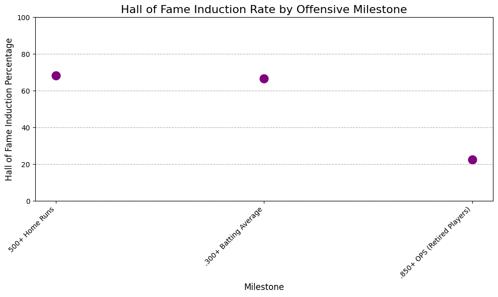

```python
plt.figure(figsize=(10, 6))
sns.scatterplot(x='Milestone', y='HOF Percentage', data=milestone_percentages, s=200, color='purple')
plt.title('Hall of Fame Induction Rate by Offensive Milestone', fontsize=16)
plt.xlabel('Milestone', fontsize=12)
plt.ylabel('Hall of Fame Induction Percentage', fontsize=12)
plt.ylim(0, 100) # Ensure the y-axis ranges from 0 to 100 for percentages
plt.grid(axis='y', linestyle='--')
plt.xticks(rotation=45, ha='right') # Rotate x-axis labels for better readability
plt.tight_layout() # Adjust layout to prevent labels from being cut off
plt.show()
```

## ANALYSIS:

A few things that limit my findings are the fact that Hall of Fame voters are not only looking for one stat, but instead an across-the-board type of player that has many different favorable statistics. Also, there are players that overlap into all three of these categories, so perhaps creating visualizations of compounded milestones (ex. only players with 500+ HRs, a .300+ batting average, and a .850+ OPS) would be a better indicator as to who would make the Hall of Fame. I bet every player in that category is in the Hall of Fame, unless they were tied up with PEDs. As well as that, there are plenty of other individual statistical milestones I could have investigated (ex. players with a career WAR over 82, or players with a career slugging percentage over .500) to get a more in-depth analysis of chances at the Hall of Fame. Going further, I think it would be interesting to do exactly what I mentioned: Compounding milestones and comparing players who check multiple impressive boxes to the numbers in the Hall of Fame. For example, we could look at players who maintained a batting average over .300, an on-base percentage over .400, and a slugging percentage over .500, since a .300/.400/.500 slash line is colloquially referred to as a "Hall of Fame slash line." I would be interested in seeing how true that is!